# Assessing the conservation status of Norwegian species and habitats for the Bern Convention in 2025

(Draft)

Authors

Bálint Czúcz

Duncan Halley

Kwaku Peprah Adjei

Nina E. Eide

Ulrika Jansson Asplund

Kim Magnus Bærum

Fia Bengtsson

Tor Erik Brandrud

Joseph Chipperfield

Jiska van Dijk

Børre Dervo

Anders Endrestøl

Hanne Hegre

Anders Kolstad

Anders Lyngstad

Jon H. Magerøy

Jan Ketil Rød

Heidi Solstad

Ole Gunnar Støen

Joachim Paul Töpper

Signe Nybø

Published

May 3, 2026

Abstract

The findings reveal that a significant number of the assessed features currently hold “Unfavourable” overall conservation status. Primary ongoing pressures affecting these species and habitats include problematic native species, infrastructure development, land conversion, and climate change. Correspondingly, top conservation measures focus on preventing natural habitat conversion and adapting forest management practices.

While the report highlights notable conservation successes—such as a tenfold population increase in the critically endangered Arctic fox due to targeted interventions like captive breeding and feeding—it also underscores severe knowledge gaps. Optimal quantitative data is largely restricted to specific monitored mammals and fish, whereas 18 species and habitat types currently suffer from highly fragmented or entirely absent foundational distribution data.

## Context and purpose

The Bern Convention, adopted in 1979, is an international treaty aimed at conserving wild plant and animal species and their natural habitats in several non-EU European and North-African countries. It legally binds its member countries to protect over 1,000 animal species and 500 plant species, focusing on species and habitats that require cross-border cooperation. A relatively new amendment (Resolution 8, 2012) extended the Bern Convention with a network of Emerald sites and the implementation of management, monitoring, and reporting measures for them. The Emerald Network is the Pan-European equivalent of the EU’s Natura 2000 network, and this resolution provides the framework for how countries designate and manage these ecological sites. In Norway the Emerald sites largely (but not entirely) correspond to the other existing protected areas (see Figure 1).

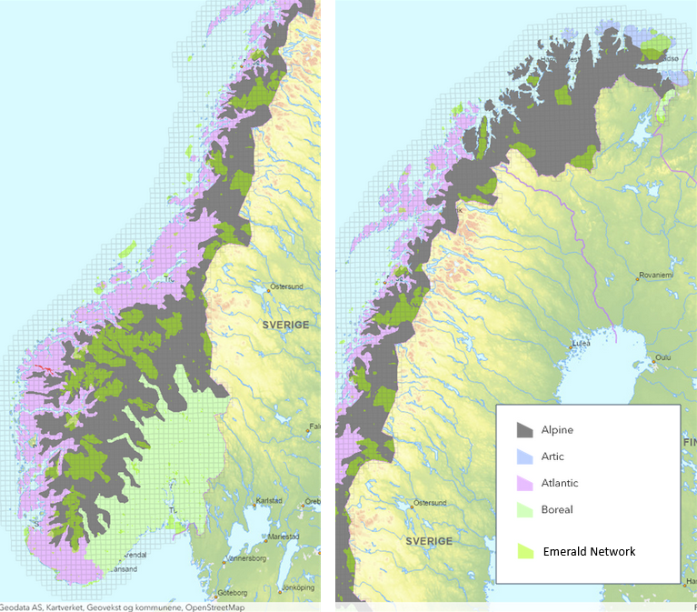

Figure 1: The four EU biogeographical regions (BGR), and the Emerald Network in Norway

According to *Resolution 8* (2012), every country must perform regular reporting about a selection of *species* and *habitat types*. As the Bern Convention has a Pan-European focus, it covers several species and habitat types that are threatened at the European level, even if they are doing relatively fine in Norway. Monitoring and reporting for such species can be considered as a vital contribution from Norway to their European-level protection. Similarly, the Resolution 8 reporting may miss some nationally/regionally endangered species and ha-bitat types if they are not under threat at the European level, which underlines why national and international monitoring and reporting must be sustained in parallel, maximising their sy-nergies.

The structure and content of the reporting, as well as its timing follows very closely the so-called “Article 17 reporting” of the EU Habitats Directive. Furthermore, both reporting processes have a *6-year cycle*, which means that for the Bern Convention countries the 2025 reporting is their second reporting altogether (the first, relatively limited reporting took place in 2019). The main purpose of the whole reporting is to assess the “*conservation status*” of the selected species and habitats in a semi-standardised way, based on the best available data and evidence.

The heart of the Resolution 8 reporting consists of a series of detailed assessments that address a number of pre-selected, species, habitat types and *biogeographic regions* (BGR, see Figure 1). For 2025 Norway received a “checklist” consisting of 74 *species* and 6 *habitat types*, which are often also called *features* collectively. Each of these features was pre-selected for *assessment* in one or more of the four EU biogeographic regions (BGR) that intersect the territory of the country.[^1] Eventually, the presence of three species was not confirmed by the experts,[^2] and the list of biogeographic regions also had to be updated for several species. This resulted in a final set 157 *full assessments* covering 71 *species* 6 *habitat types* across the four biogeographic regions of Norway (Table 1).[^3] The full list of the species and habitat types assessed and the main assessment conclusions is presented in Annexes 1 & 2.

Table 1: The number of *features* (i.e. species & habitat types: N<sub>features</sub>) and *assessments* (detailed expert evaluations for a feature in a biogeofraphic region: N<sub>assessments</sub>). Features (species, habitats) with insignificant, uncertain, or historical occurrences in a biogeographic region were recorded without a detailed assessment (MAR: Features near their natural range limits with insignificant abundance/area in the studied region; EXp: Species extinct before the Bern Convention entered into force (1982); SCR: Features with an uncertain occurrence in the studied region).

| Feature groups | N<sub>features</sub> | N<sub>assessments</sub> | Special cases MAR | Special cases EXp | Special cases SCR |
| --- | --- | --- | --- | --- | --- |
| Mammals (ma) | 7 | 25 | — | — | — |
| Fishes & amphibians (fa) | 6 | 15 | — | — | 2 |
| Insects and molluscs (im) | 15 | 23 | — | 1 | 5 |
| Vascular plants (vp) | 34 | 47 | 5 | 1 | 2 |
| Mosses (mo) | 14 | 30 | 1 | 1 | 3 |
| Habitat types (ht) | 6 | 17 | — | — | 2 |
| Total | 82 | 157 | 6 | 3 | 14 |

## Conservation status of species and habitat types

We start with presenting an overview of the conclusions of the assessments. Each assessment has an overall conclusion, which is based on four “parameters”, each of which has its own conclusions. The conclusions for the individual parameters rely on quantitative and qualitative data collected by taxonomic experts following detailed guidelines provided by the Bern Secretariat. The four assessment parameters for species include its *distribution range* (Ran), *population size* (Pop), the quality and quantity of the *available habitat* for the species (H4s), and its *future prospects* (Fpr) based on the balance of pressures and conservation measures. All conclusions are evaluated in a simple “traffic light system” using one of the following four *conservation status* categories:

- **FV**: Favourable (green),
- **U1**: Unfavourable - inadequate (amber),
- **U2**: Unfavourable - bad (red),
- **XX**: Unknown (grey).

### Species assessments

Table 2 provides an overview of the overall conclusions across the major species groups, whereas Table 3 shows the distribution of the partial conclusions for the individual parameters across all the species.

Table 2: Distribution of overall conclusions across the different groups of features (FV: Favourable; U1: Unfavourable - inadequate; U2: Unfavourable - bad; XX: Unknown)

| Species groups | FV | U1 | U2 | XX |
| --- | --- | --- | --- | --- |
| Mammals (ma) | 3 | 18 | 4 | — |
| Fishes & amphibians (fa) | — | 2 | 4 | 9 |
| Insects and molluscs (im) | 2 | 2 | 12 | 7 |
| Vascular plants (vp) | 1 | 24 | 19 | 3 |
| Mosses (mo) | 5 | — | 25 | — |
| All (all) | 11 | 46 | 64 | 19 |

Table 3: Distribution of partial conclusions over the different parameters (FV: Favourable; U1: Unfavourable - inadequate; U2: Unfavourable - bad; XX: Unknown)

| Assessment parameters | FV | U1 | U2 | XX |
| --- | --- | --- | --- | --- |
| Range (Ran) | 46 | 8 | 18 | 68 |
| Population (Pop) | 25 | 17 | 10 | 88 |
| Habitat for species (H4s) | 41 | 28 | 51 | 20 |
| Future prospects (Fpr) | 14 | 68 | 38 | 20 |
| Overall conclusion (OvC) | 11 | 46 | 64 | 19 |

Below we also visualise the distribution of the conclusions across the different species groups and assessment parameters (Figure 2).

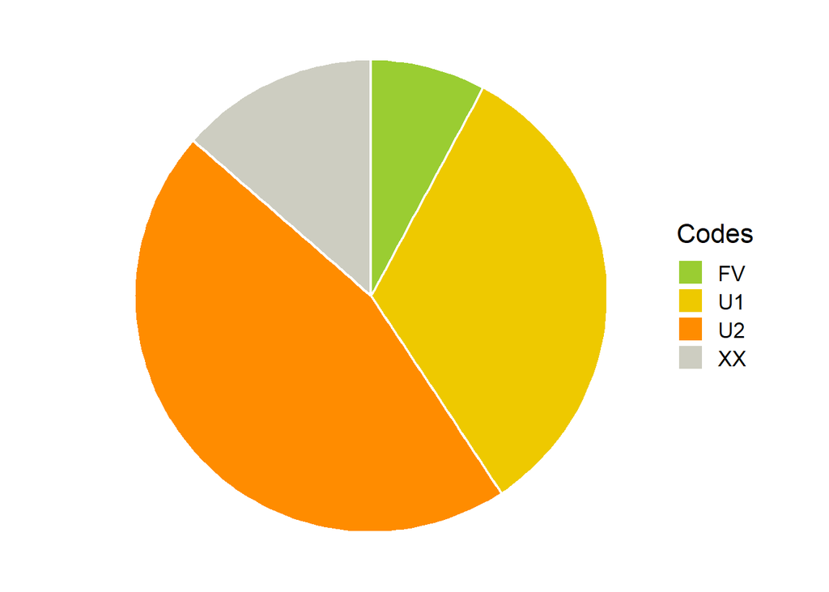

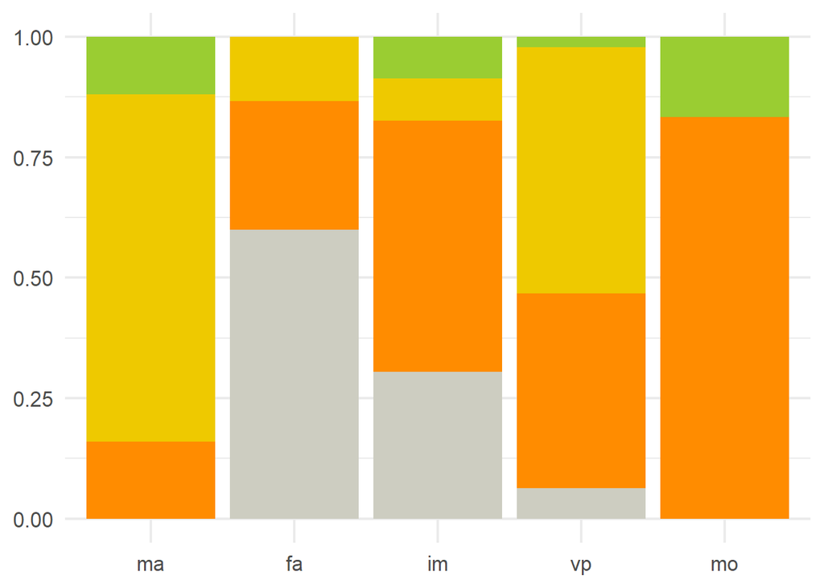

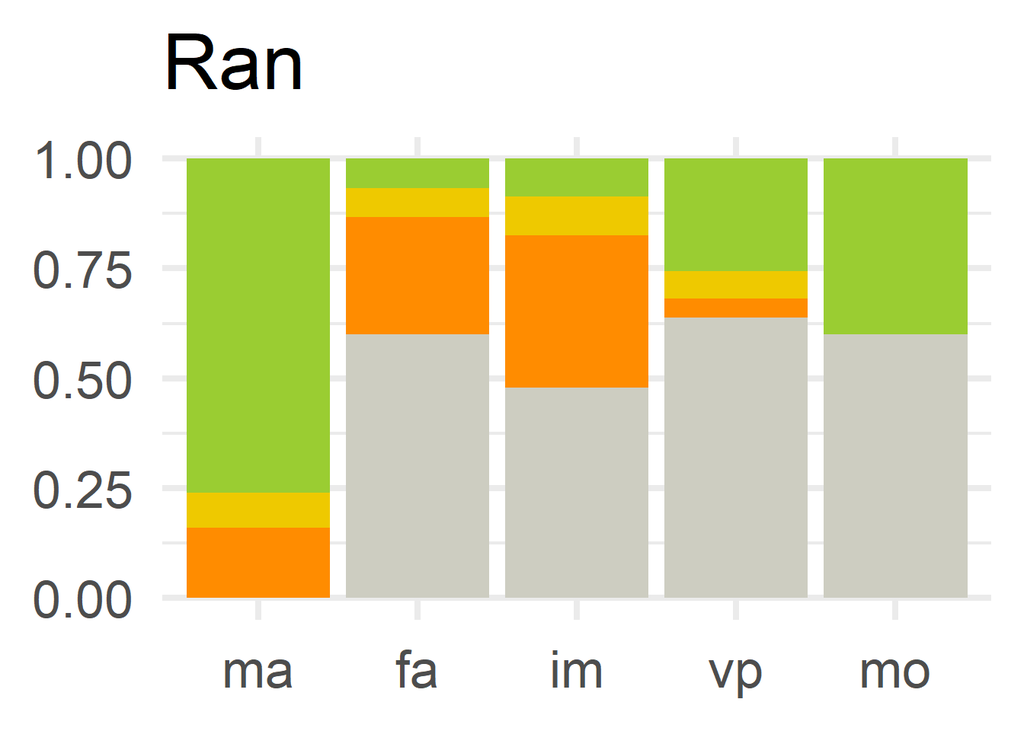

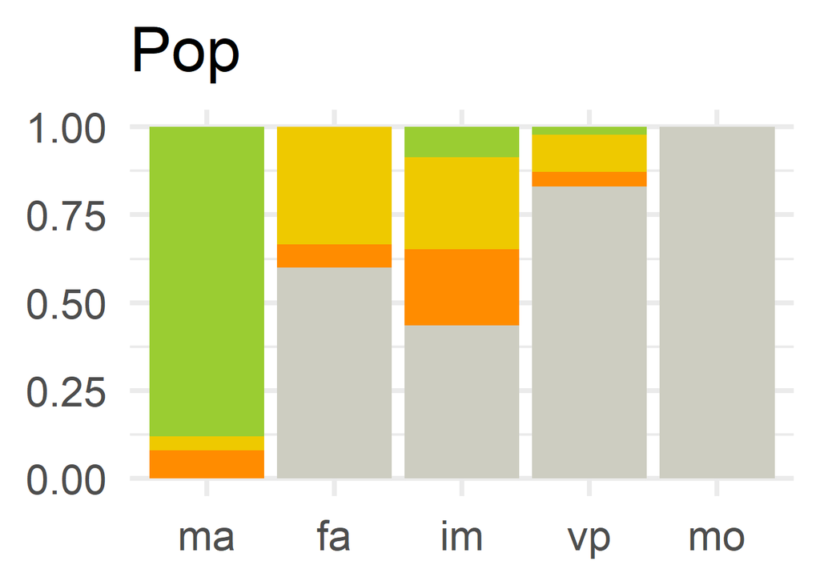

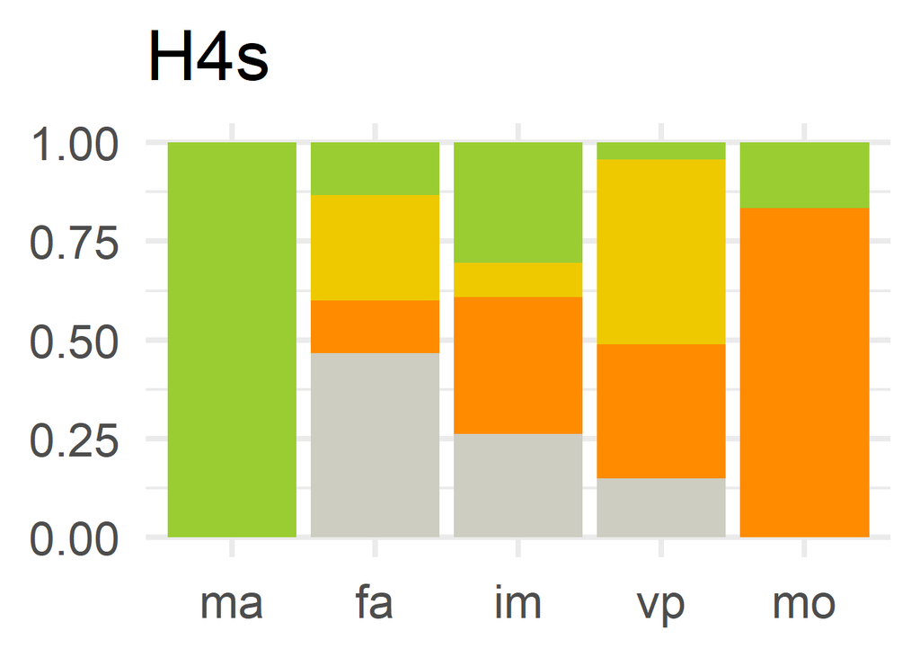

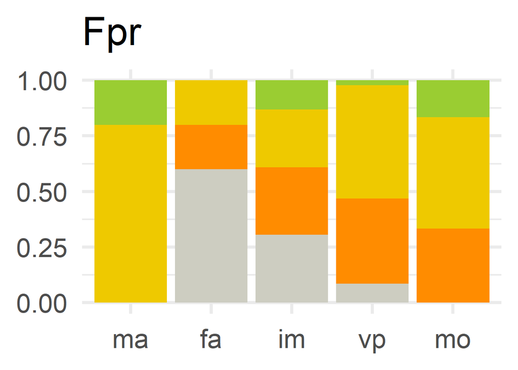

Figure 2: The conclusions of the species assessments in the 2025 reporting of Norway to the Bern Convention (Resultion 8). Top row: overall conclusions for all species (pie chart) and for major species groups (columns). Bottom row: partial conclusions for the four main assessment parameters.

### Habitat type assessments

Table 4 and Figure 3 provide an overview of the different conclusions for the habitat types assessed in 2025 in Norway.

Table 4: Distribution of partial conclusions over the different parameters (FV: Favourable; U1: Unfavourable - inadequate; U2: Unfavourable - bad; XX: Unknown)

| Assessment parameters | FV | U1 | U2 | XX |
| --- | --- | --- | --- | --- |
| Range (Ran) | 15 | — | 2 | — |
| Area of habitats (Are) | — | 1 | 12 | 4 |
| Structure and function (SnF) | — | 5 | 12 | — |
| Future prospects (Fpr) | — | 5 | 12 | — |
| Overall conclusion (OvC) | — | 5 | 12 | — |

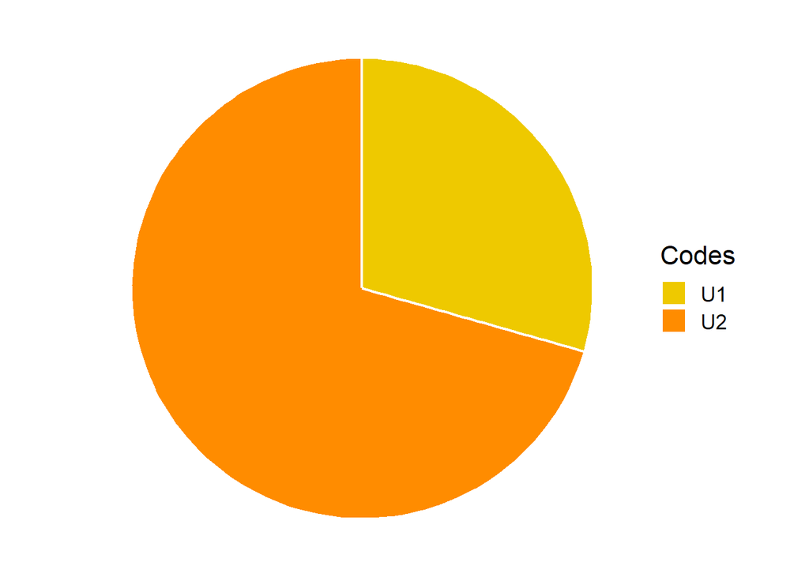

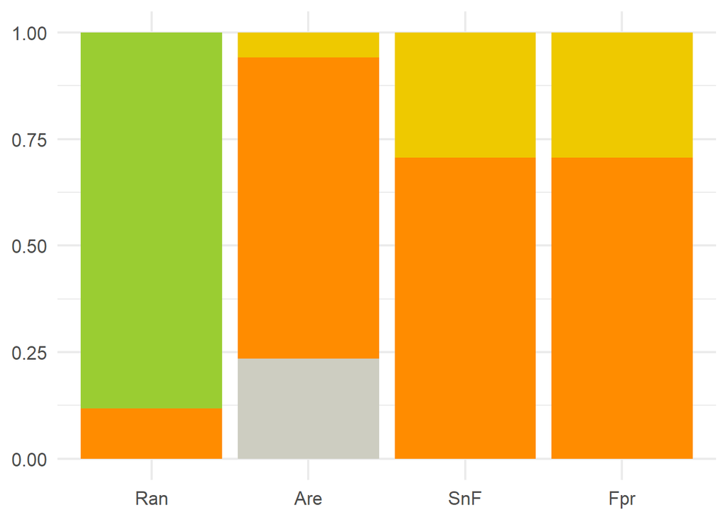

Figure 3: The conclusions of habitat type assessments in the 2025 reporting of Norway to the Bern Convention (Resultion 8). Left: overall conclusions for all habitat types (pie chart); right: partial conclusions for the four main assessment parameters (Ran: range, Are: area, SnF: structure and function, Fpr: future prospects)

## Changes and trends

The assessment protocol offers several ways to describe past, present and future trends in the conservation status of the studied species and habitats. This includes the assessment of the *short-term* and *long-term* trends by the experts participating in the 2025 assessment, as well as a direct comparisons of the consecutive assessments (e.g comparing the conservation status of the same species & habitats assessed in 2019 and 2025). In the context of the Bern Convention *short-term trends* always refer to the past 12 years (i.e. 2013-2024 in this case), whereas *long term trends* are referring to the 24 year period before the assessment date (i.e. 2001-2024). In addition, the parameter *future prospects* discussed in the previous section also addresses trends, synthesizing expectations for changes in the other three parameters during the forthcoming 12 years (i.e. 2025-2036).

In the next few sections we provide an overview of the main current and past trends relying on the different elements of the Bern assessment protocol.

### Short term trends

Short term trends are first assessed individually for the different state parameters (range, population size, and habitat availability for species, and range, area, and structure/function for habitat types), and then the directions of these elementary trends are aggregated into an *overall trend qualifier*, which is the second flagship output of Bern Convention assessments, providing critical insights for the interpretation of the *overall conservation status*. In Figure 4 we provide an overview of these trend qualifiers for the different groups of features.

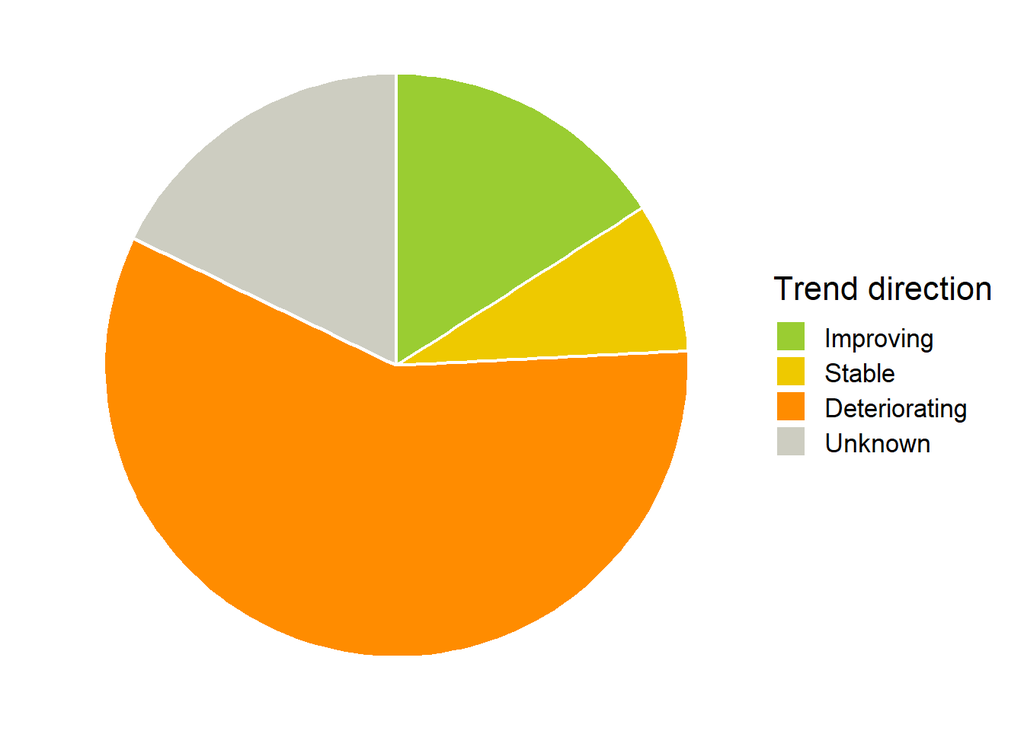

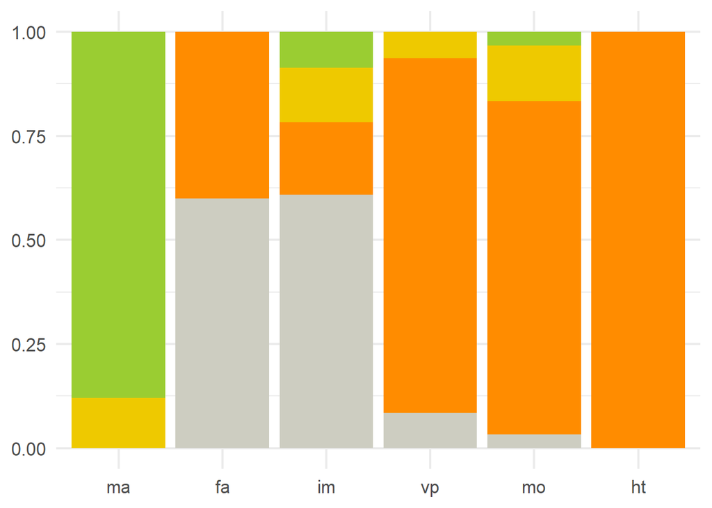

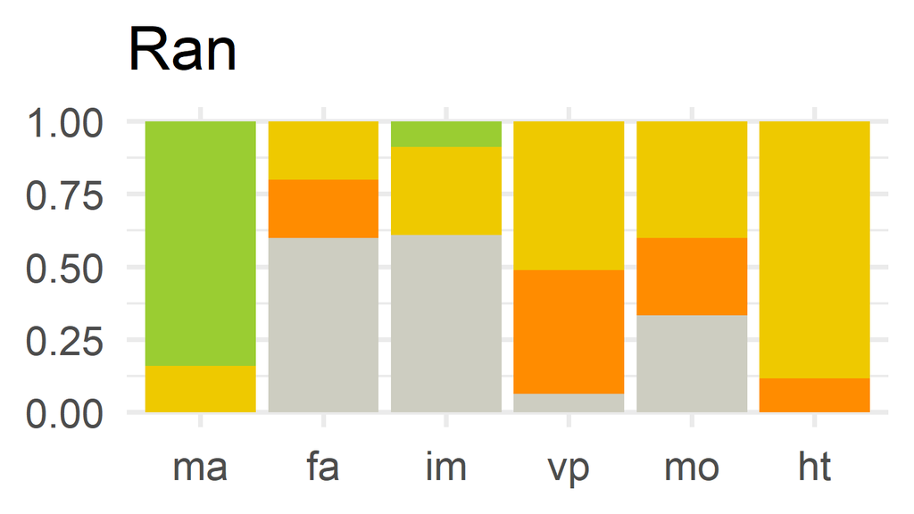

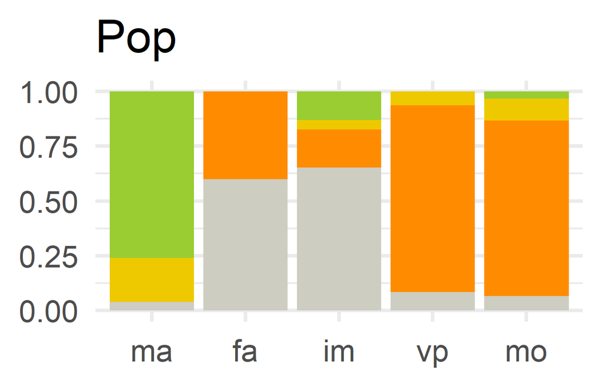

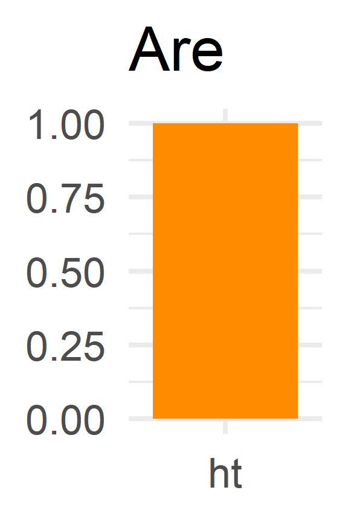

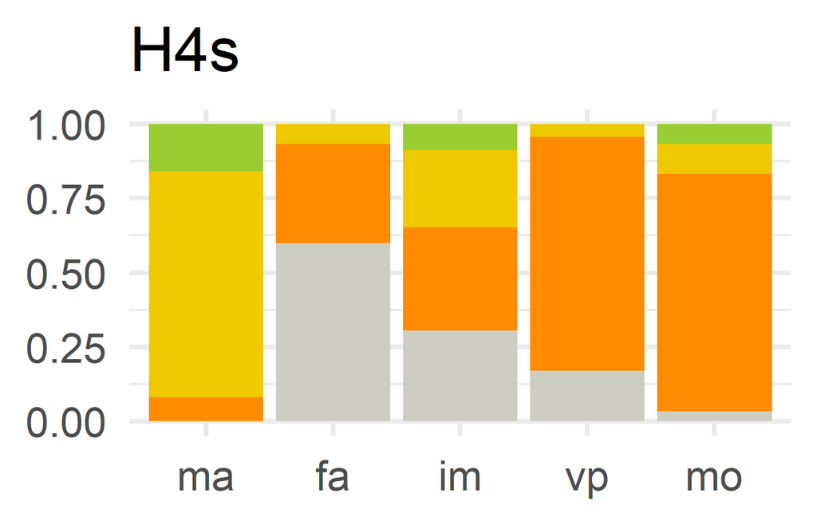

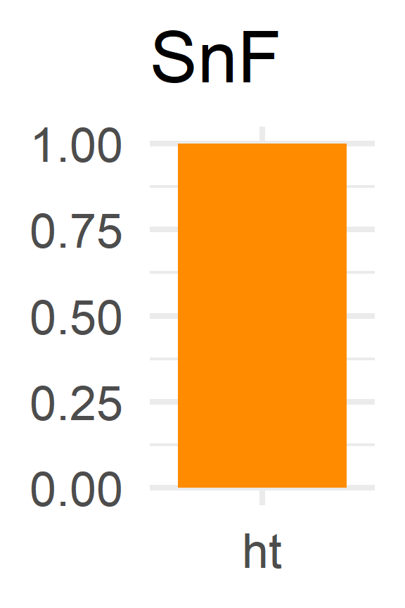

Figure 4: Overall short-term (2013-2024) trends identified during the 2025 assessments. Top row: the overall “*trend qualifiers*” among all assessments (pie chart) and the distribution of trend types across the main groups of features (columns). Bottom row: short term trends for the main assessment parameters. (ma: mammals, fa= fishes & amphibians, im= insects and molluscs, vp: vascular plants, mo: mosses, ht: habitat types; Ran: range, Pop: population, Are: area, H4s: habitat for species, SnF: structure and function)

### Changes in conservation status since 2019

The 2019 reporting period was the first reporting period for Norway under Resolution 8 of the Bern Convention. This reporting period was considered to be a pilot exercise by the Bern Convention Secretariat, so only very few species and habitat types were selected for reporting. Table 5 provides an overview of the changes in the overall assessment conclusions for the overlapping species.

Table 5: Changes in the overall conclusions of the repeated assessments between 2019 and 2025 (FV: Favourable; U1: Unfavourable - inadequate; U2: Unfavourable - bad; XX: Unknown)

| Change | N | Assessments |
| --- | --- | --- |
| U2 --> U2 | 5 | Alvemose (ATL, BOR); eremitt (BOR); rikmyr (ATL, BOR) |
| U1 --> U1 | 4 | Marisko (ALP, ATL, BOR); rikmyr (ALP) |
| U1 --> U2 | 4 | Alvemose (ALP); gulflekktorvlibelle (ATL); lågurtedellauvskog (ATL, BOR) |
| XX --> U1 | 4 | Brunbjørn (ALP, BOR); ulv (ALP, BOR) |
| XX --> XX | 3 | Bekkeniøye (ATL, BOR); smalknøttsnegl (BOR) |
| FV --> U1 | 2 | Oter (ARC, ATL) |
| FV --> U2 | 2 | Oter (ALP, BOR) |
| U2 --> U1 | 2 | Myrsildre (ALP, ATL) |
| FV --> XX | 1 | Hvitfinnet steinulk (BOR) |
| U1 --> FV | 1 | Gulflekktorvlibelle (BOR) |

If the overall conservation status of a species/habitat changed since 2019 then the experts were were requested to assess the main reasons for the change. They could select more then one reason from a list that included *genuine change*, changes in *data* or *methods*. The results are summarised in Table 6.

Table 6: The main reasons for changes in the overall conclusions since 2019

[output not shown]

## Background factors

A major element of the Bern Convention (Resolution 8) reporting protocol is the assessment of *pressures* (i.e. threats) and *conservation measures* affecting the status and trends of the selected species and habitat types. These factors have a key role in the assessment of the *future prospects* parameter, but and they can also provide relevant information by themselves, e.g. for effective conservation planning. The assessment protocol offers a long list of predefined types of pressures and conservation measures, and the experts could choose from these lists, assigning an ordered list of *pressures* and *measures* to each species and habitat type.

### Key pressures

Beyond just listing the relevant pressures the experts also had to characterise them from three different perspectives: its timing (past, ongoing or expected future pressure), extent (the share of the population/area it affects), and influence (the degree of impact on the affected population/area). Table 7 presents an overview of the pressures that were most commonly listed as “ongoing” threats across all species and habitat types.

Table 7: The 20 most most commmon active (ongoing) pressures identified during the assessments (N: number of assessments where the given pressure was identified; ma: mammals, fa= fishes & amphibians, im= insects and molluscs, vp: vascular plants, mo: mosses, ht: habitat types)

Kode

Påvirkningsfaktor beskrivelse (en)

N

Artsgrupper

ma

fa

im

vp

mo

ht

PI03

Problematic native species

42

[figure not shown]

PE01

Roads, paths, railroads and related infrastructure

41

[figure not shown]

PF01

Conversion from other land uses to built-up areas

39

[figure not shown]

PJ03

Changes in precipitation regimes due to climate change

34

[figure not shown]

PJ01

Temperature changes and extremes due to climate change

32

[figure not shown]

PD02

Hydropower (dams, weirs, run-off-the-river and respective infrastructure)

28

[figure not shown]

PB09

Clear-cutting, removal of all trees

27

[figure not shown]

PF03

Creation or development of sports, tourism and leisure infrastructure

27

[figure not shown]

PJ10

Change of habitat location, size, and / or quality due to climate change

27

[figure not shown]

PA05

Abandonment of management/use of grasslands and other agricultural and agroforestry systems (e.g. cessation of grazing, mowing or traditional farming)

25

[figure not shown]

PF13

Drainage, land reclamation and conversion of wetlands, marshes, bogs, etc. for built-up areas

23

[figure not shown]

PG11

Illegal shooting/killing

20

[figure not shown]

PB24

Drainage for forestry

19

[figure not shown]

PB06

Logging or thinning (excluding clear cutting)

18

[figure not shown]

PA13

Application of natural or synthetic fertilisers on agricultural land

16

[figure not shown]

PG08

Hunting

16

[figure not shown]

PA07

Intensive grazing or overgrazing by livestock

14

[figure not shown]

PB23

Physical alteration of water bodies for forestry (including dams)

13

[figure not shown]

PB01

Conversion to forest from other land uses, or afforestation (excluding drainage)

12

[figure not shown]

PI02

Other invasive alien species (other than species of Bern Convention concern)

12

[figure not shown]

### Main conservation measures

Similarly to the pressures, the experts also identified the most important conservation measures for each feature in each biogeographic region. This included all “ongoing” (actively implemented) conservation measures, as well as any clearly useful, but not yet implemented measures. In addition, for each already implemented measure the experts also documented if the measures were implemented only within the Emerald sites, or also beyond them. Table 8 presents an overview of the most frequently mentioned conservation measures.

Table 8: The ten most relevant conservation measures, as identified during the assessments (N: number of assessments where the given measure was identified; ma: mammals, fa: fishes & amphibians, im: insects and molluscs, vp: vascular plants, mo: mosses, ht: habitat types)

Kode

Bevaringstiltak beskrivelse (en)

N

Artsgrupper

ma

fa

im

vp

mo

ht

MA01

Prevent conversion of natural and semi-natural habitats, and habitats of species into agricultural land

24

[figure not shown]

MB06

Stop forest management and exploitation practices

24

[figure not shown]

MB05

Adapt/change forest management and exploitation practices

23

[figure not shown]

MB01

Prevent conversion of (semi-) natural habitats into forests and of (semi-) natural forests into intensive forest plantation

21

[figure not shown]

MB14

Manage drainage and water abstraction for forestry (inc. restoration of drained or hydrologically altered habitats)

20

[figure not shown]

ME01

Reduce impact of transport operation and infrastructure

19

[figure not shown]

ME06

Habitat restoration of areas impacted by transport

18

[figure not shown]

MC04

Reduce impact of hydropower operation and infrastructure (incl. the restoration of freshwater habitats)

17

[figure not shown]

MF01

Managing the impacts of converting land for construction and development of infrastructure

17

[figure not shown]

MA03

Maintain existing extensive agricultural practices and agricultural landscape features

16

[figure not shown]

### Role of the Emerald Network

Protected areas, and in particular the Emerald Network is assumed to provide substantial support for endangered species and habitats. Several parts of the Bern assessment explore the influence of the Emerald Network, thus providing useful feedback for conservation management. In Table 9 we compare *within Emerald* short-term trends of several parameters with the general trends of the same parameters within the entire biogeographic region. This comparison is only sensitive to the direction of the trend, so significant differences between slight and drastic declines (or improvements) can still be marked as “same within/beyond Emerald” in Table 9.

Table 9: Comparison of short term trends in several parameters within the Emerald network and outside of it.

| Trends within/beyond Emerald | Population (Pop) | Habitat for species (H4s) | Area of habitats (Are) | Structure and function (SnF) |
| --- | --- | --- | --- | --- |
| Better *within* Emerald | 1 | 2 | 15 | 13 |
| Same trend within/beyond | 72 | 82 | 2 | 4 |
| Better *beyond* Emerald | 3 | 1 | — | — |
| Unknown (at least partly) | 64 | 55 | — | — |

```r
# A quick temporary overview of the most interesting cases of the table above:
tmp2 %>%
  filter(para %in% c("Pop", "H4s"), cc2 %in% c("better", "worse")) %>%
  mutate(species=map_chr(spp, \(x) str_c(x, collapse=", "))) %>%
  select(para, cc2, species) %>%
  print
```

```
# A tibble: 4 × 3
  para  cc2    species
  <chr> <fct>  <chr>
1 H4s   better grønnsko, russeburkne
2 Pop   better grønnsko
3 H4s   worse  oter
4 Pop   worse  gulflekktorvlibelle, oter
```

In addition we can also compare the implementation of the conservation measures within and beyond the Emerald Network based on the answers of the experts. Table 10 offers such a comparison.

Table 10: The location of the most frequently implemented conservation measures: predominantly within Emerald sites (N<sub>in</sub>), mostly outside of the Emerald Network (N<sub>out</sub>), or both within and beyond Emerald (N<sub>i.o</sub>)

| Code | Conservation measure name | N<sub>tot</sub> | N<sub>in</sub> | N<sub>i.o</sub> | N<sub>out</sub> |
| --- | --- | --- | --- | --- | --- |
| MG02 | Management of hunting, recreational fishing, and the recreational or commercial harvesting or collection of plants and fungi (incl. restoration of habitats) | 7 | 0 | 5 | 2 |
| MS04 | Manage native species (incl. species which are not protected by the Bern Convention / Resolution No. 6 (1998)) | 5 | 1 | 2 | 2 |
| MA01 | Prevent conversion of natural and semi-natural habitats, and habitats of species into agricultural land | 4 | 0 | 0 | 4 |
| MA03 | Maintain existing extensive agricultural practices and agricultural landscape features | 4 | 0 | 3 | 1 |
| MG01 | Management of professional/commercial fishing, shellfish and seaweed harvesting (incl. restoration of habitats) | 4 | 0 | 2 | 2 |
| MI03 | Management, control or eradication of other invasive alien species | 4 | 0 | 3 | 1 |
| MS01 | Reinforce populations of species from the Resolution No. 6 (1998) | 4 | 1 | 0 | 3 |
| MB14 | Manage drainage and water abstraction for forestry (inc. restoration of drained or hydrologically altered habitats) | 3 | 0 | 0 | 3 |
| MC04 | Reduce impact of hydropower operation and infrastructure (incl. the restoration of freshwater habitats) | 3 | 0 | 2 | 1 |
| ME06 | Habitat restoration of areas impacted by transport | 3 | 0 | 0 | 3 |

## Bevaring av fjellreven en suksess – tidobling av bestanden

Fjellreven har lenge vært kritisk truet i Norge. Arten ble fredet allerede i 1930, men fortsatte å gå tilbake. Bestanden var trolig allerede da for liten til å respondere positivt på vern, samtidig ble det observert store endring i smågnagerdynamikken og økt forekomst av rødrev på tundraen, som kan ha påvirket fjellreven negativt. Rundt 2000 antok man at bestanden bare talte 40-60 voksne individer i Norge, Sverige og Finland til sammen. Arten var da svært nær å bli utryddet. Med bakgrunn i den første handlingsplanen for arten, kom tiltakene i Norge i gang fra 2005. Avlsprogrammet for fjellrev ble da etablert på fjellet og har per nå satt ut over 500 fjellrev. I tillegg til å reetablere fem utdødde norske delbestander har utsatte fjellrever bidratt til å styrke mange av de gjenværende delbestandene i Fennoskandia og også medført reetablering i Finland. Det ble da også satt i gang støttefôring, og det er per nå mer enn 150 fôrautomater i drift gjennom hele året i så godt som hele utbredelsen. Det tredje tiltaket, systematisk uttak av rødrev, gjøres bare i den nordligste delen av utbredelsen, og ellers bare der rødreven er i direkte konkurranse med fjellreven. Tiltakene har resultert i en tidobling av bestanden, nå beregnet til å være over 300 voksne fjellrev i Norge. Som følge av det ble fjellreven listet til sterkt truet i 2021 (Figure 5).

I Norge finnes fjellreven bare i det alpine og arktiske biomet, hvorav 85-90% i det alpine tundrabiomet. Bare 10-15% av bestanden finnes utenfor Emerald nettverket. Beskyttelsen verneområdene er gitt, blant annet gjennom strenge restriksjoner på utbygging av infrastruktur, anlegg og bygninger har trolig bidratt sterkt til at det fortsatt er bæreevne for fjellrev i disse områdene. Restriksjoner på utbygging i store deler av tundrabiomet gjør at områdene beholder sin naturlige marginalitet som høyfjellsartene er særdeles godt tilpasset. Økt menneskelig aktivitet fører alltid med seg høyere tetthet av generalistarter, blant annet rødrev, som kan fortrenge fjellreven om den opptrer i høye tettheter.

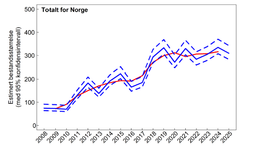

Figure 5: Estimert bestandsstørrelse (med 95 % konfidensintervaller) for fjellrev i Norge i perioden 2008–2025, basert på en lukket fangst-gjenfangst modell bygget på innsamlet DNA-materiale i den samme perioden. Rød linje viser glidende gjennomsnitt over 3-årsperioder. Merk at gjennomsnittses-timatene er sentrert, dvs. estimatet for 2023–2025 vises som estimat på 2024 i figuren. (Fra Jackson mfl. 2025)

Vern av leveområdene, omfang og ikke minst varigheten av tiltakene har vært avgjørende for suksessen av bevaringsarbeidet. Tross suksessen og tidoblingen, er fjellrevbestanden fortsatt langt fra å være levedyktig, blant annet på grunn av lav konnektivitet og utfordringer med innavl. Forskerne anslår at tiltakene må vedvare med samme intensitet 10-15 år til, før man kan begynne å trappe ned arbeidet. Bevaringsarbeidet er finansiert av Miljødirektoratet, tidvis med bidrag fra InterReg. Det praktiske arbeidet gjøres i hovedsak av Statens naturoppsyn, NINA har ansvar for den faglige koordineringen av tiltakene og overvåking av bestanden, samt drift av avlsprogrammet (Figure 6).

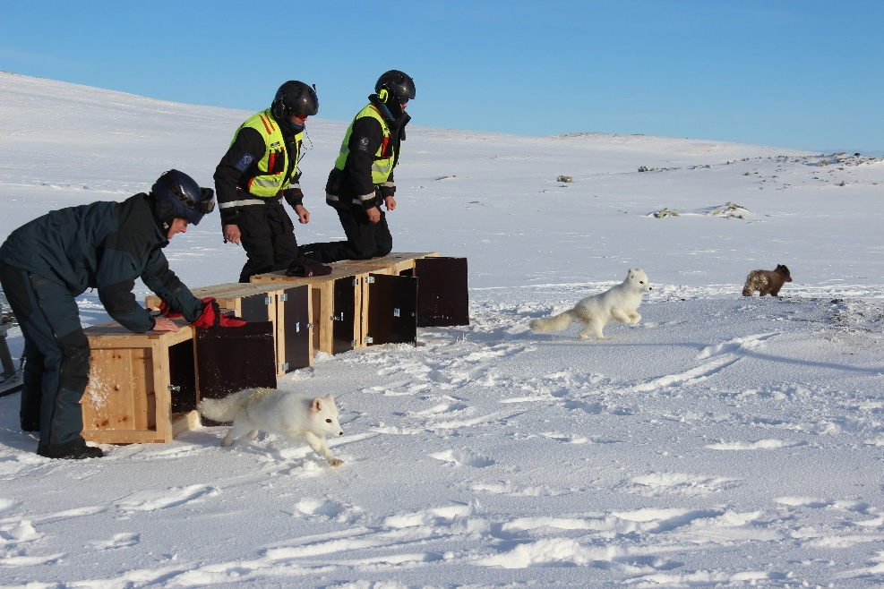

Figure 6: Utsetting av fjellrev i Hardangervidda nasjonalpark, en del av Emerald Nettverket (Foto: Toralf Mjøen, Avlsprogrammet, NINA)

## Data availability

Resolution 8 Assessments for the Bern Convention rely on several types of data. The most important data types include detailed *spatial data* characterising the actual distribution of the studied species and habitat types, reliable *quantitative data* about the actual population size (species) or area extent (habitats), and a reliable quantitative *reference level* for this population/area. While spatial distribution and quantitative population/extent can change rapidly, and thus demand careful monitoring, the reference levels only need to established once (e.g. using population viability modelling techniques), and then they can be reused in subsequent reporting cycles. These data types are also necessary for proper conservation planning and management at the national level. In Table 11 we provide an overview of the availability of these key data types.[^4]

Table 11: The studied species and habitats grouped according to data availability

| Data availability | N | Features (species, habitat types) |
| --- | --- | --- |
| Reliable quantitative data with ref.levels | 6 | Ulv, brunbjørn, gaupe, jerv, fjellrev, laks |
| Reliable quantitative data without ref.levels | 1 | Sibinattfiol |
| Partial/expert data with ref.levels | 7 | Oter, bever, storsalamander, elvemusling, læstadiusvalmue, huldregras, kveinhavre |
| Partial/expert data without ref.levels | 8 | Myrsildre, polarjonsokblom, stammesigd, sporebustehette, stakesvanemose, buttklokkemose, huldrebekkemose, alvemose |
| Spat. distribution data & qualitative estimates | 42 | Gulflekktorvlibelle, D. latissimus, G. bilineatus, eremitt, furuhettebille, polarblåvinge, dvergperlemorvinge, P. ruficollis, fiolett gullvinge, dvergmarinøkkel, flytegro, mykt havfruegress, marisko, … |
| No or very fragmented data | 18 | Havniøye, bekkeniøye, elveniøye, hvitfinnet steinulk, granhettebille, rikmyrknøttsnegl, smalknøttsnegl, kalkkildeknøttsnegl, russegras, kløftstarr, aremose, storskortemose, sigdfauskmose, sanddynetrau… |

For most of the species, data availability is a major limitation for Bern Convention assessments. There are relatively few species with «optimal» data availability, including mainly charismatic and economically important mammal and fish species with dedicated monitoring programmes. For most of the Bern species and habitat types there are some spatial distribution data available (covering more than 75% of the presumable distribution of the species), but there are no representative monitoring programmes. For 18 species and habitat types, however, even their basic spatial distribution is poorly known. For habitat types this is often also related to the differences between the Norwegian national habitat typologies (e.g. NiN 2.3 or 3.0) and the EUNIS typology used by the Bern Convention.

## Annexes

- A checklist overview (a) table with all species & habitats (incl latin & norsk names, rødlista status, etc) plus the list of the selected BGRs (occurrence code PRE: 2019 final, 2025 initial, 2025 final)
- The “fact sheets” produced for the individual species/habitats

## Footnotes

[^1]: In the context of the Bern Convention, assessing one feature (a species or a habitat type) in one region is counted as “one assessment”.
[^2]: Stag beetle (*Lucanus cervus*) was never observed in Norway, and two species, the beetle *Stephanopachys substriatus* and the orchid *Liparis loeselei* disappeared from Norway before the Bern Convention entered into force.
[^3]: Pre-defined special cases (e.g. species/habitats with *marginal presence* (MAR) or uncertain occurrence (*scientific reserve*, SCR)) in the studied region. For these *occurrence categories* we did not provide a detailed assessment in this assessment period.
[^4]: For the main quantitative fields the experts had to characterise the methodology and their level of certainty (high/medium/low “quality of information”). Here we started out from these responses.